# WRF DataProject

RukayatBalogun

2024-05-12

## DATASET AND DATA UNDERSTANDING

```r
#install.packages("readxl")
#install.packages("zoo")
#install.packages("dplyr")
library(readxl)
library(dplyr)
library(zoo)
```

#### readxl

readxl is a package for reading Excel files into R, which enables us to import data from Excel spreadsheets

#### dplyr

dplyr is a package for data manipulation in R, providing a set of functions for data manipulation talks like filtering, selecting, arranging, summarizing, and mutating data

#### zoo

zoo is a package for working with regular and irregular time series data in R. This package provide convenient structures for handling time series data, including varioys methods for indexing, merging, and analyzing time series data.

### Data Importation

```r
data <- read_excel("/Users/whitegg/Documents/GitHub/Bolton/Bolton c/Semester Two/Dataset/Weather copy.xlsx")
df <- data

head(data)
```

```
## # A tibble: 6 × 2,482
##   X      X.1   X01.05.2018.00.00 X.2   X.3   X.4   X.5   X.6   X.7   X.8   X.9
##   <chr>  <chr> <chr>             <chr> <chr> <chr> <chr> <chr> <chr> <chr> <chr>
## 1 XLAT   XLONG TSK               PSFC  "\"U… "\"V… "\"Q… RAINC RAIN… SNOW  TSLB
## 2 48.871 -11.… NA                1014… "6.9" "5.5" "0.0… 0.0   0.0   0.0   273.2
## 3 49.010 -11.… 285.2             1013… "7.0" "5.8" "0.0… 0.0   0.0   0.0   273.2
## 4 49.149 -11.… 285.2             1013… "7.0" "6.0" "0.0… 0.0   0.0   0.0   273.2
## 5 49.288 -11.… 285.2             1013… "7.0" "6.3" "0.0… 0.0   0.0   0.0   273.2
## 6 49.427 -11.… 285.2             1012… "7.0" "6.6" "0.0… 0.0   0.0   0.0   273.2
## # ℹ 2,471 more variables: X.10 <chr>, X01.05.2018.03.00 <chr>, X.11 <chr>,
## #   X.12 <chr>, X.13 <chr>, X.14 <chr>, X.15 <chr>, X.16 <chr>, X.17 <chr>,
## #   X.18 <chr>, X.19 <chr>, X01.05.2018.06.00 <chr>, X.20 <chr>, X.21 <chr>,
## #   X.22 <chr>, X.23 <chr>, X.24 <chr>, X.25 <chr>, X.26 <chr>, X.27 <chr>,
## #   X.28 <chr>, X01.05.2018.09.00 <chr>, X.29 <chr>, X.30 <chr>, X.31 <chr>,
## #   X.32 <chr>, X.33 <chr>, X.34 <chr>, X.35 <chr>, X.36 <chr>, X.37 <chr>,
## #   X01.05.2018.12.00 <chr>, X.38 <chr>, X.39 <chr>, X.40 <chr>, X.41 <chr>, …
```

### Filtering

```r
#graduate the first row to column header
colnames(data) <- data[1, ]

#remove the first row from dataset
data <- data[-1, ]

#Check the number of rows
num_rows <- nrow(data)
num_rows
```

```
## [1] 5451
```

```r
# Check the number of columns
num_cols <- ncol(data)
num_cols
```

```
## [1] 2482
```

```r
# Filter records where XLAT and XLONG match the target values 53°49'N   03°03'W
filtered_data <- subset(data, XLAT == '53.490' & XLONG=='2.985')
View(filtered_data)

filtered_data
```

```
## # A tibble: 1 × 2,482
##   XLAT   XLONG TSK   PSFC  `"U10"` `"V10"` `"Q2"` RAINC RAINNC SNOW  TSLB  SMOIS
##   <chr>  <chr> <chr> <chr> <chr>   <chr>   <chr>  <chr> <chr>  <chr> <chr> <chr>
## 1 53.490 2.985 280.6 99821 9.5     -10.7   0.005… 0.0   3.7    0.0   273.2 1.00…
## # ℹ 2,470 more variables: TSK <chr>, PSFC <chr>, `"U10"` <chr>, `"V10"` <chr>,
## #   `"Q2"` <chr>, RAINC <chr>, RAINNC <chr>, SNOW <chr>, TSLB <chr>,
## #   SMOIS <chr>, TSK <chr>, PSFC <chr>, `"U10"` <chr>, `"V10"` <chr>,
## #   `"Q2"` <chr>, RAINC <chr>, RAINNC <chr>, SNOW <chr>, TSLB <chr>,
## #   SMOIS <chr>, TSK <chr>, PSFC <chr>, `"U10"` <chr>, `"V10"` <chr>,
## #   `"Q2"` <chr>, RAINC <chr>, RAINNC <chr>, SNOW <chr>, TSLB <chr>,
## #   SMOIS <chr>, TSK <chr>, PSFC <chr>, `"U10"` <chr>, `"V10"` <chr>, …
```

```r
#XLONG AND LAT REMOVED
location <- filtered_data[,-c(1,2)]
```

### Data Transformation

```r
# Define the total number of columns in the dataset
total_columns <- ncol(location)



row_matrix <- matrix(as.numeric(location), ncol=10,byrow = TRUE)
```

[output not shown]

[output cut: 111 more lines]

[output not shown]

```r
head(row_matrix)
```

```
##       [,1]   [,2] [,3]  [,4]    [,5] [,6] [,7] [,8]  [,9] [,10]
## [1,] 280.6  99821  9.5 -10.7 0.00582    0  3.7    0 273.2     1
## [2,] 280.6 100038 12.0  -8.2 0.00577    0  8.0    0 273.2     1
## [3,] 280.6 100231 13.2  -6.1 0.00536    0 10.7    0 273.2     1
## [4,] 280.6 100543 11.5  -4.3 0.00498    0 10.7    0 273.2     1
## [5,] 280.6 100809  8.3   1.9 0.00513    0 10.7    0 273.2    NA
## [6,] 280.6 100861  2.7   6.5 0.00555    0 10.7    0 273.2     1
```

```r
coldata <- colnames(df[,-c(1,2)])
head(coldata)
```

```
## [1] "X01.05.2018.00.00" "X.2"               "X.3"
## [4] "X.4"               "X.5"               "X.6"
```

```r
dates <- function(coldata) {
  dt <- grep("^X[0-9]{2}\\.[0-9]{2}\\.[0-9]{4}\\.[0-9]{2}\\.[0-9]{2}$", coldata, value= TRUE)
  return(dt)
}

dates <- lapply(coldata, dates)
head(dates)
```

```
## [[1]]
## [1] "X01.05.2018.00.00"
##
## [[2]]
## character(0)
##
## [[3]]
## character(0)
##
## [[4]]
## character(0)
##
## [[5]]
## character(0)
##
## [[6]]
## character(0)
```

```r
dates <- unlist(dates)
head(dates)
```

```
## [1] "X01.05.2018.00.00" "X01.05.2018.03.00" "X01.05.2018.06.00"
## [4] "X01.05.2018.09.00" "X01.05.2018.12.00" "X01.05.2018.15.00"
```

```r
dataset <- data.frame(
  dateTime = dates,
  TSK = row_matrix[,1],
  PSFC = row_matrix[,2],
  U10 = row_matrix[,3],
  V10 = row_matrix[,4],
  Q2= row_matrix[,5],
  RAINC = row_matrix[,6],
  RAINNC = row_matrix[,7],
  SNOW = row_matrix[,8],
  TSLB =  row_matrix[,9],
  SMOIS =  row_matrix[,10]
)
head(dataset)
```

```
##            dateTime   TSK   PSFC  U10   V10      Q2 RAINC RAINNC SNOW  TSLB
## 1 X01.05.2018.00.00 280.6  99821  9.5 -10.7 0.00582     0    3.7    0 273.2
## 2 X01.05.2018.03.00 280.6 100038 12.0  -8.2 0.00577     0    8.0    0 273.2
## 3 X01.05.2018.06.00 280.6 100231 13.2  -6.1 0.00536     0   10.7    0 273.2
## 4 X01.05.2018.09.00 280.6 100543 11.5  -4.3 0.00498     0   10.7    0 273.2
## 5 X01.05.2018.12.00 280.6 100809  8.3   1.9 0.00513     0   10.7    0 273.2
## 6 X01.05.2018.15.00 280.6 100861  2.7   6.5 0.00555     0   10.7    0 273.2
##   SMOIS
## 1     1
## 2     1
## 3     1
## 4     1
## 5    NA
## 6     1
```

```r
summary(dataset)
```

```
##    dateTime              TSK             PSFC             U10
##  Length:248         Min.   :280.2   Min.   : 99821   Min.   :-8.400
##  Class :character   1st Qu.:282.5   1st Qu.:101483   1st Qu.:-4.375
##  Mode  :character   Median :283.3   Median :101937   Median :-2.050
##                     Mean   :283.3   Mean   :101822   Mean   :-1.686
##                     3rd Qu.:283.9   3rd Qu.:102288   3rd Qu.: 0.775
##                     Max.   :288.0   Max.   :102770   Max.   :13.200
##                     NA's   :17      NA's   :5        NA's   :6
##       V10                Q2               RAINC       RAINNC             SNOW
##  Min.   :-11.300   Min.   :0.004980   Min.   :0   Min.   : 0.0000   Min.   :0
##  1st Qu.: -5.200   1st Qu.:0.006593   1st Qu.:0   1st Qu.: 0.0000   1st Qu.:0
##  Median : -1.700   Median :0.007360   Median :0   Median : 0.0000   Median :0
##  Mean   : -1.705   Mean   :0.007250   Mean   :0   Mean   : 0.4846   Mean   :0
##  3rd Qu.:  1.600   3rd Qu.:0.007700   3rd Qu.:0   3rd Qu.: 0.0000   3rd Qu.:0
##  Max.   : 14.300   Max.   :0.009870   Max.   :0   Max.   :16.2000   Max.   :0
##  NA's   :7         NA's   :8          NA's   :7   NA's   :7         NA's   :4
##       TSLB           SMOIS
##  Min.   :273.2   Min.   :1
##  1st Qu.:273.2   1st Qu.:1
##  Median :273.2   Median :1
##  Mean   :273.2   Mean   :1
##  3rd Qu.:273.2   3rd Qu.:1
##  Max.   :273.2   Max.   :1
##  NA's   :9       NA's   :13
```

In the above figure, I have transformed the data to a matrix and converted to a numeric and double using the position the matrix. The result of the data after transformation shows the I Have 11 columns, 248 rows. *Datetime* column shows the data and time of each entry and the interval is 3 hours, *TSK* represents the skin temperature or surface temperature measured in Kelvin, *PSFC* measures the surface pressure in Pascal, *U10 , V10* measures in m/s the component of the wind in X and Y respectively. *Q2* measures the Humidity in kg, *Rainc and Rainnc* measures the conventive and non-conventive rain precipitation measured in Mm respectively, *Snow* records the snow water equivalent measured in kg/m2, *TSLB* records the soil temperature in oK, while *SMOIS* records the soil moisture in m3.

### Cleaning DateTime

```r
# Replace 'X' with an empty string in the specified column
dataset <- dataset %>%
  mutate(dateTime = sub("X", "", dateTime))

# View the modified dataset
head(dataset)
```

```
##           dateTime   TSK   PSFC  U10   V10      Q2 RAINC RAINNC SNOW  TSLB
## 1 01.05.2018.00.00 280.6  99821  9.5 -10.7 0.00582     0    3.7    0 273.2
## 2 01.05.2018.03.00 280.6 100038 12.0  -8.2 0.00577     0    8.0    0 273.2
## 3 01.05.2018.06.00 280.6 100231 13.2  -6.1 0.00536     0   10.7    0 273.2
## 4 01.05.2018.09.00 280.6 100543 11.5  -4.3 0.00498     0   10.7    0 273.2
## 5 01.05.2018.12.00 280.6 100809  8.3   1.9 0.00513     0   10.7    0 273.2
## 6 01.05.2018.15.00 280.6 100861  2.7   6.5 0.00555     0   10.7    0 273.2
##   SMOIS
## 1     1
## 2     1
## 3     1
## 4     1
## 5    NA
## 6     1
```

```r
#Split the datetime into Date and Time


dataset$date <- substr(dataset$dateTime, 2, 11)
head(dataset)
```

```
##           dateTime   TSK   PSFC  U10   V10      Q2 RAINC RAINNC SNOW  TSLB
## 1 01.05.2018.00.00 280.6  99821  9.5 -10.7 0.00582     0    3.7    0 273.2
## 2 01.05.2018.03.00 280.6 100038 12.0  -8.2 0.00577     0    8.0    0 273.2
## 3 01.05.2018.06.00 280.6 100231 13.2  -6.1 0.00536     0   10.7    0 273.2
## 4 01.05.2018.09.00 280.6 100543 11.5  -4.3 0.00498     0   10.7    0 273.2
## 5 01.05.2018.12.00 280.6 100809  8.3   1.9 0.00513     0   10.7    0 273.2
## 6 01.05.2018.15.00 280.6 100861  2.7   6.5 0.00555     0   10.7    0 273.2
##   SMOIS       date
## 1     1 1.05.2018.
## 2     1 1.05.2018.
## 3     1 1.05.2018.
## 4     1 1.05.2018.
## 5    NA 1.05.2018.
## 6     1 1.05.2018.
```

```r
dataset$time <- substr(dataset$dateTime, 12, 17)
head(dataset)
```

```
##           dateTime   TSK   PSFC  U10   V10      Q2 RAINC RAINNC SNOW  TSLB
## 1 01.05.2018.00.00 280.6  99821  9.5 -10.7 0.00582     0    3.7    0 273.2
## 2 01.05.2018.03.00 280.6 100038 12.0  -8.2 0.00577     0    8.0    0 273.2
## 3 01.05.2018.06.00 280.6 100231 13.2  -6.1 0.00536     0   10.7    0 273.2
## 4 01.05.2018.09.00 280.6 100543 11.5  -4.3 0.00498     0   10.7    0 273.2
## 5 01.05.2018.12.00 280.6 100809  8.3   1.9 0.00513     0   10.7    0 273.2
## 6 01.05.2018.15.00 280.6 100861  2.7   6.5 0.00555     0   10.7    0 273.2
##   SMOIS       date  time
## 1     1 1.05.2018. 00.00
## 2     1 1.05.2018. 03.00
## 3     1 1.05.2018. 06.00
## 4     1 1.05.2018. 09.00
## 5    NA 1.05.2018. 12.00
## 6     1 1.05.2018. 15.00
```

In this phase, I have replaced the string “X” in the column with an empty string. The *datetime* column has now been split into Date and Time. The next phase of data cleaning is to check if the data has outliers and how best to deal with it.

### Missing Values

```r
summary(dataset)
```

```
##    dateTime              TSK             PSFC             U10
##  Length:248         Min.   :280.2   Min.   : 99821   Min.   :-8.400
##  Class :character   1st Qu.:282.5   1st Qu.:101483   1st Qu.:-4.375
##  Mode  :character   Median :283.3   Median :101937   Median :-2.050
##                     Mean   :283.3   Mean   :101822   Mean   :-1.686
##                     3rd Qu.:283.9   3rd Qu.:102288   3rd Qu.: 0.775
##                     Max.   :288.0   Max.   :102770   Max.   :13.200
##                     NA's   :17      NA's   :5        NA's   :6
##       V10                Q2               RAINC       RAINNC             SNOW
##  Min.   :-11.300   Min.   :0.004980   Min.   :0   Min.   : 0.0000   Min.   :0
##  1st Qu.: -5.200   1st Qu.:0.006593   1st Qu.:0   1st Qu.: 0.0000   1st Qu.:0
##  Median : -1.700   Median :0.007360   Median :0   Median : 0.0000   Median :0
##  Mean   : -1.705   Mean   :0.007250   Mean   :0   Mean   : 0.4846   Mean   :0
##  3rd Qu.:  1.600   3rd Qu.:0.007700   3rd Qu.:0   3rd Qu.: 0.0000   3rd Qu.:0
##  Max.   : 14.300   Max.   :0.009870   Max.   :0   Max.   :16.2000   Max.   :0
##  NA's   :7         NA's   :8          NA's   :7   NA's   :7         NA's   :4
##       TSLB           SMOIS        date               time
##  Min.   :273.2   Min.   :1    Length:248         Length:248
##  1st Qu.:273.2   1st Qu.:1    Class :character   Class :character
##  Median :273.2   Median :1    Mode  :character   Mode  :character
##  Mean   :273.2   Mean   :1
##  3rd Qu.:273.2   3rd Qu.:1
##  Max.   :273.2   Max.   :1
##  NA's   :9       NA's   :13
```

Based on observation, the date and time observation above the attribute row start at the beginning of every TSK column in the dataset , there is a missing date and time at the final TSK column. I fixed this manually by imputing the missing observation as this might have been caused by data imputation or omission error. The result shows thet all columns have NAs and since they all have different measurement, I will be fixing the values individually. To do this, I will use linear interpolation which is a method that returns the mean of given points in the data. So the value of the na varies depending on the previous and next value to the missing value.

```r
library('zoo')
#replace NA values using Linear Interpolation

dataset$TSK <- na.approx(dataset$TSK )


dataset$PSFC <- na.approx(dataset$PSFC )


dataset$U10 <- na.approx(dataset$U10 )


dataset$V10 <- na.approx(dataset$V10 )


dataset$Q2 <- na.approx(dataset$Q2 )


dataset$RAINC <- na.approx(dataset$RAINC )


dataset$SNOW <- na.approx(dataset$SNOW )


dataset$TSLB <- na.approx(dataset$TSLB )


dataset$SMOIS <- na.approx(dataset$SMOIS )

dataset$RAINNC <- na.approx(dataset$RAINNC, na.rm = FALSE)

dataset$RAINNC[is.na(dataset$RAINNC)] <- 0

summary(dataset)
```

```
##    dateTime              TSK             PSFC             U10
##  Length:248         Min.   :280.2   Min.   : 99821   Min.   :-8.400
##  Class :character   1st Qu.:282.5   1st Qu.:101483   1st Qu.:-4.150
##  Mode  :character   Median :283.3   Median :101933   Median :-2.100
##                     Mean   :283.3   Mean   :101824   Mean   :-1.672
##                     3rd Qu.:283.9   3rd Qu.:102285   3rd Qu.: 0.825
##                     Max.   :288.0   Max.   :102770   Max.   :13.200
##       V10                Q2               RAINC       RAINNC            SNOW
##  Min.   :-11.300   Min.   :0.004980   Min.   :0   Min.   : 0.000   Min.   :0
##  1st Qu.: -5.100   1st Qu.:0.006615   1st Qu.:0   1st Qu.: 0.000   1st Qu.:0
##  Median : -1.700   Median :0.007370   Median :0   Median : 0.000   Median :0
##  Mean   : -1.651   Mean   :0.007259   Mean   :0   Mean   : 0.471   Mean   :0
##  3rd Qu.:  1.625   3rd Qu.:0.007715   3rd Qu.:0   3rd Qu.: 0.000   3rd Qu.:0
##  Max.   : 14.300   Max.   :0.009870   Max.   :0   Max.   :16.200   Max.   :0
##       TSLB           SMOIS       date               time
##  Min.   :273.2   Min.   :1   Length:248         Length:248
##  1st Qu.:273.2   1st Qu.:1   Class :character   Class :character
##  Median :273.2   Median :1   Mode  :character   Mode  :character
##  Mean   :273.2   Mean   :1
##  3rd Qu.:273.2   3rd Qu.:1
##  Max.   :273.2   Max.   :1
```

### Linear Interpolation

LI is a method of estimating values between two known data points on a line or curve . It assumes that there is a linear relationship between the data points. Linear interpolation is commonly used when you have a set of data points and you want to estimate the value of a point that falls between two given point. In this case, I have used LI to get the moving average of two points and have used the value to replace the NA values.

### Outliers

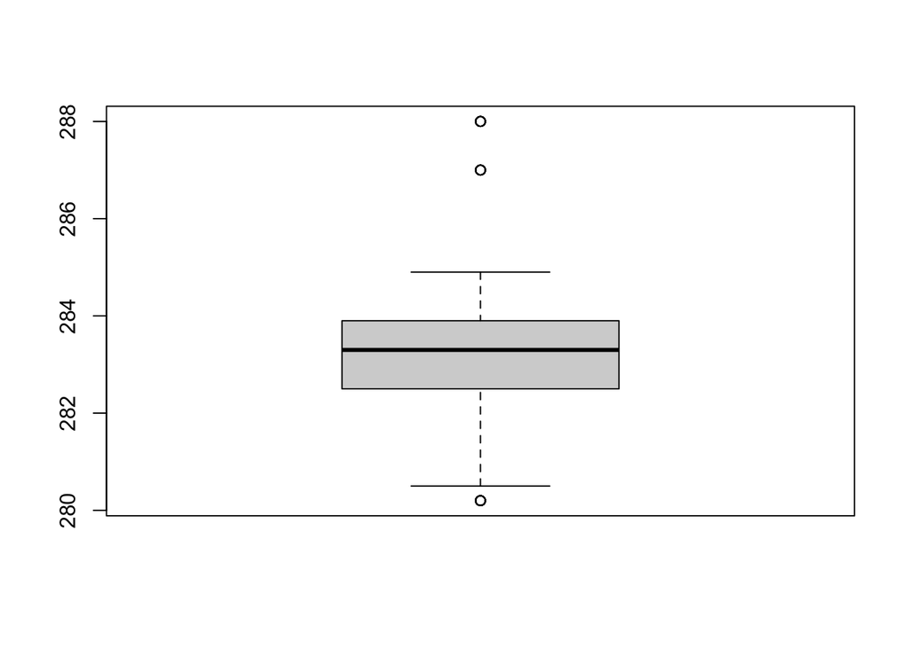

```r
#Check for outlier (tsoutlier)
boxplot(dataset$TSK)
```

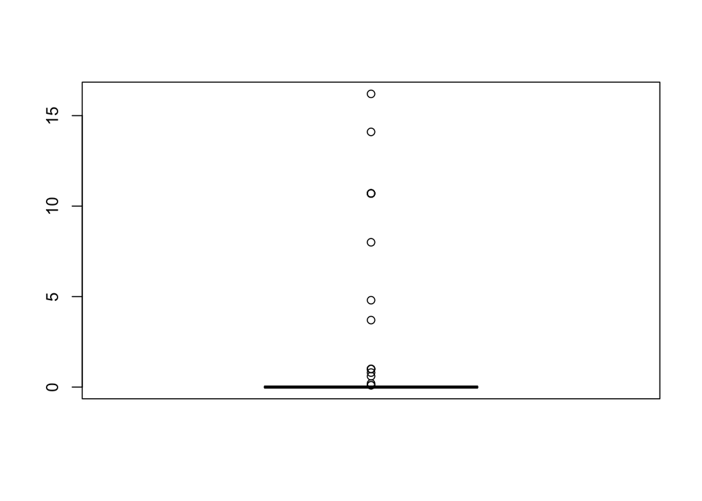

```r
boxplot(dataset$RAINNC,
        data=dataset
)
```

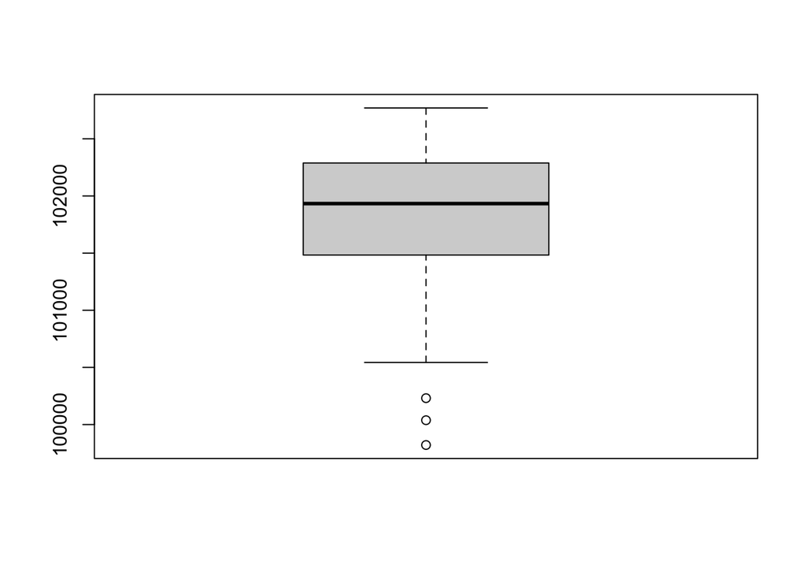

```r
boxplot(dataset$PSFC,
        data=dataset
)
```

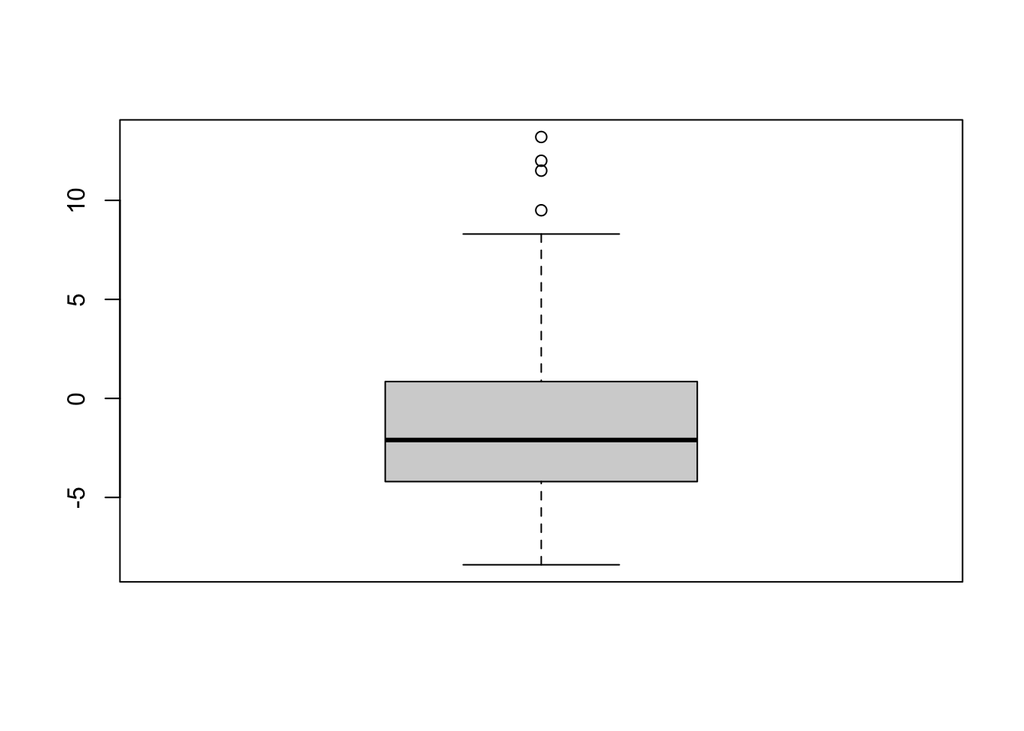

```r
boxplot(dataset$U10,
        data=dataset
)
```

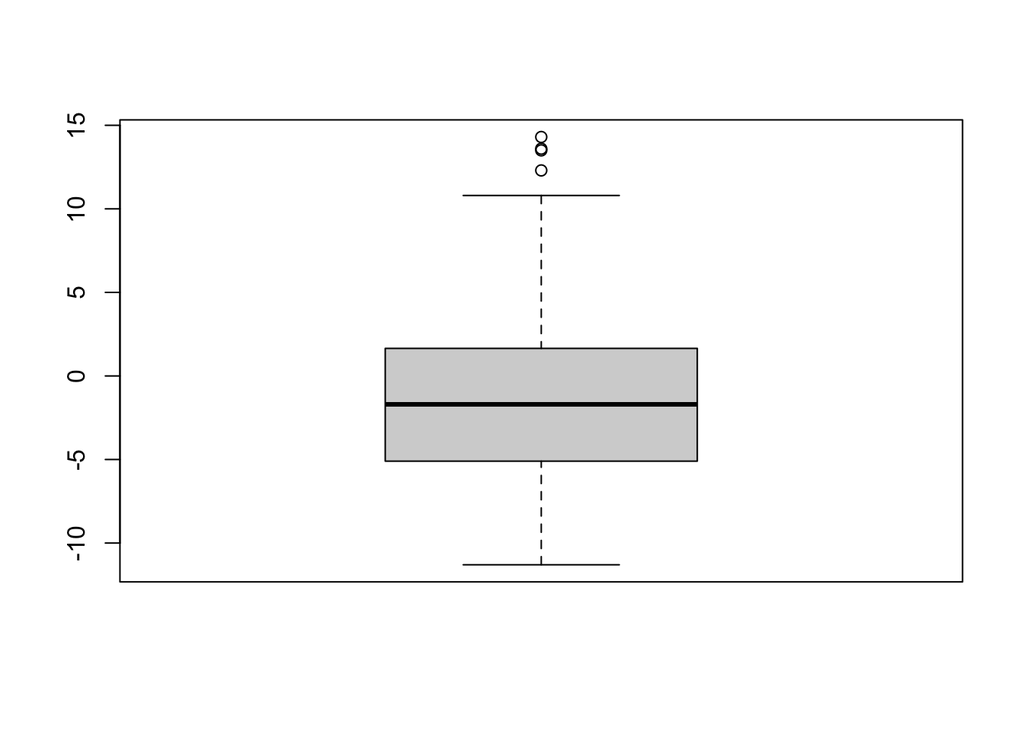

```r
boxplot(dataset$V10,
        data=dataset
)
```

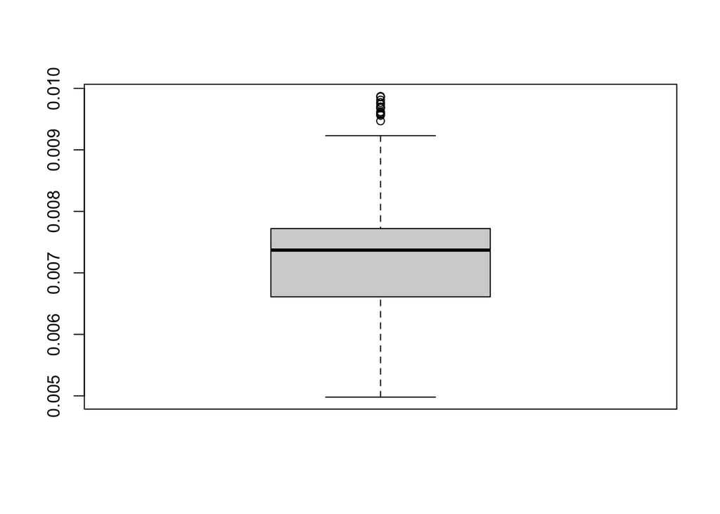

```r
boxplot(dataset$Q2,
        data=dataset
)
```

The figure above shows there are outliers in the columns. I will investigate to check the distribution of the dataset if truely its an outlier

```r
#calculate the 25% quantile
tskq1 <- quantile(dataset$TSK, 0.25)
tskq1
```

```
##   25%
## 282.5
```

```r
#calculate the 75% quantile
tskq3 <-  quantile(dataset$TSK, 0.75)
tskq3
```

```
##   75%
## 283.9
```

```r
#substract the 25% from the 75% quantile
tskiqr <- tskq3 - tskq1
tskiqr
```

```
## 75%
## 1.4
```

```r
#upper limit
tskul <- tskq3 + 1.5*tskiqr
tskul
```

```
## 75%
## 286
```

```r
#lower limit
tskll <- tskq1 - 1.5*tskiqr
tskll
```

```
##   25%
## 280.4
```

```r
#identify the outliers in the dataset
tskoutliers <- dataset$TSK[dataset$TSK < tskll | dataset$TSK > tskul ]
tskoutliers
```

```
##  [1] 280.2 280.2 280.2 280.2 280.2 280.2 280.2 280.2 288.0 288.0 288.0 288.0
## [13] 288.0 288.0 288.0 288.0 287.0 287.0 287.0 287.0 287.0 287.0 287.0 287.0
```

The above result shows the distribution of outliers in the dataset. I will be using winsorization to deal with the outliers

```r
#install.packages(DescTools)

library(DescTools)
dataset$TSK <- Winsorize(dataset$TSK, probs= c(0.05, 0.95))
dataset$RAINNC <- Winsorize(dataset$RAINNC, probs= c(0.05, 0.95))
dataset$U10 <- Winsorize(dataset$U10, probs= c(0.05, 0.95))
dataset$V10 <- Winsorize(dataset$V10, probs= c(0.05, 0.95))
dataset$Q2 <- Winsorize(dataset$Q2, probs= c(0.05, 0.95))


summary(dataset)
```

```
##    dateTime              TSK             PSFC             U10
##  Length:248         Min.   :280.5   Min.   : 99821   Min.   :-7.300
##  Class :character   1st Qu.:282.5   1st Qu.:101483   1st Qu.:-4.150
##  Mode  :character   Median :283.3   Median :101933   Median :-2.100
##                     Mean   :283.3   Mean   :101824   Mean   :-1.804
##                     3rd Qu.:283.9   3rd Qu.:102285   3rd Qu.: 0.825
##                     Max.   :287.0   Max.   :102770   Max.   : 4.895
##       V10               Q2               RAINC       RAINNC             SNOW
##  Min.   :-9.600   Min.   :0.005617   Min.   :0   Min.   :0.00000   Min.   :0
##  1st Qu.:-5.100   1st Qu.:0.006615   1st Qu.:0   1st Qu.:0.00000   1st Qu.:0
##  Median :-1.700   Median :0.007370   Median :0   Median :0.00000   Median :0
##  Mean   :-1.798   Mean   :0.007260   Mean   :0   Mean   :0.06774   Mean   :0
##  3rd Qu.: 1.625   3rd Qu.:0.007715   3rd Qu.:0   3rd Qu.:0.00000   3rd Qu.:0
##  Max.   : 6.160   Max.   :0.009529   Max.   :0   Max.   :1.00000   Max.   :0
##       TSLB           SMOIS       date               time
##  Min.   :273.2   Min.   :1   Length:248         Length:248
##  1st Qu.:273.2   1st Qu.:1   Class :character   Class :character
##  Median :273.2   Median :1   Mode  :character   Mode  :character
##  Mean   :273.2   Mean   :1
##  3rd Qu.:273.2   3rd Qu.:1
##  Max.   :273.2   Max.   :1
```

### Duplicates

```r
which(duplicated(dataset))
```

```
## integer(0)
```

This result shows we have no duplicate in the dataset

## Visualization

### Multivariate Visualization

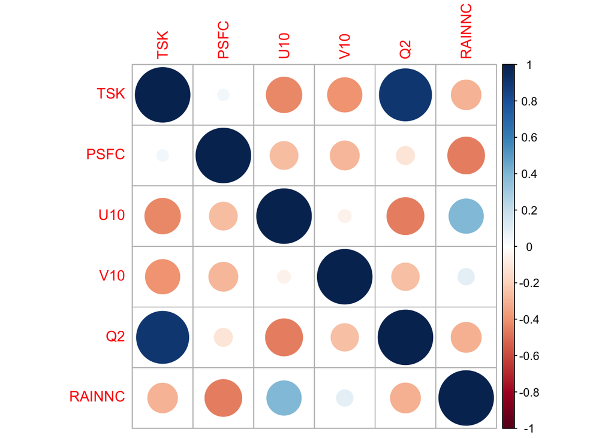

```r
#install.packages("ggplot2")
#install.packages("corrplot")

# Load necessary libraries
library(ggplot2)
library(corrplot)
columns_of_interest <- dataset[, c("TSK", "PSFC", "U10", "V10", "Q2","RAINNC")]

# Multivariate Analysis - Correlation plot
correlation_matrix <- cor(columns_of_interest)
corrplot(correlation_matrix, method = "circle")
```

The Mutlivariate visualization shows there is a strong positive correlation with TSK and Q2, weak positive correlation with Rainnc and U10 , V10 and Rainnc.

### Bivariate Visualization

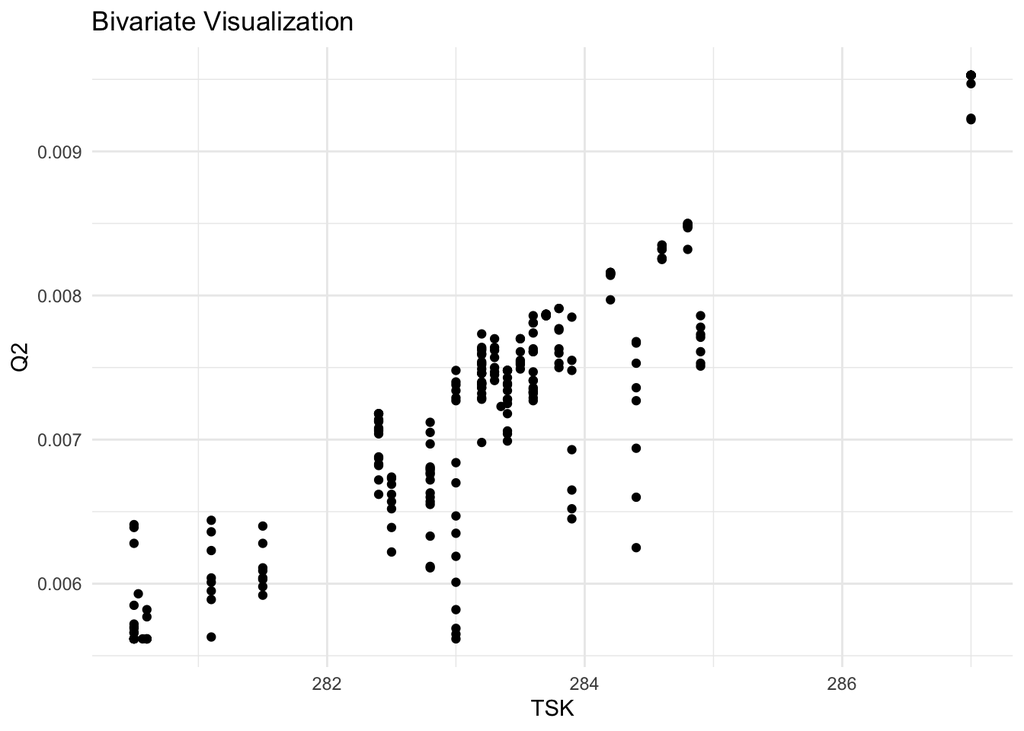

```r
# Bivariate Analysis - Scatter plots
ggplot(data = dataset, aes(x = TSK, y = Q2)) +
  geom_point() +
  labs(title = "Bivariate Visualization", x = "TSK", y = "Q2") +
  theme_minimal()
```

The result of the visualization shows there Skin Temperature has a positive effect on the humidity of a particular region. That is, in the summer, air temperature is higher and holds more water vapour, which raises the level of humidity. High humidity makes temperatures feel hotter, even stifling, because all the water vapour in the air makes it difficult for sweat to evaporate from our skin.

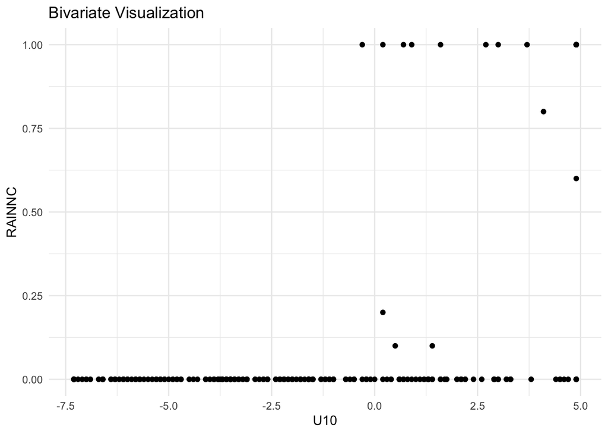

```r
ggplot(data = dataset, aes(x = U10, y = RAINNC)) +
  geom_point() +
  labs(title = "Bivariate Visualization", x = "U10", y = "RAINNC") +
  theme_minimal()
```

The result shows a weak positive relation between the Component of the wind and non-conventive Rain. Which means that the direction of the wind has an impact also the directional tilt of the raindrops, which in turn determines the angle of raindrop impact on the soil surface.

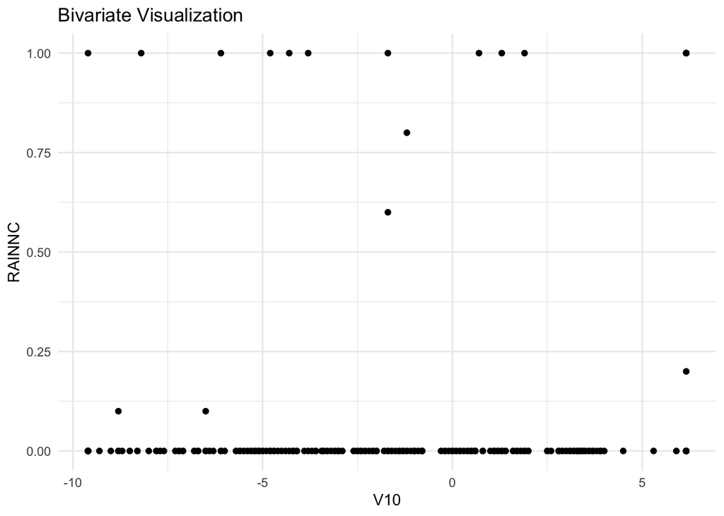

```r
ggplot(data = dataset, aes(x = V10, y = RAINNC)) +
  geom_point() +
  labs(title = "Bivariate Visualization", x = "V10", y = "RAINNC") +
  theme_minimal()
```

### Univariate Visualization

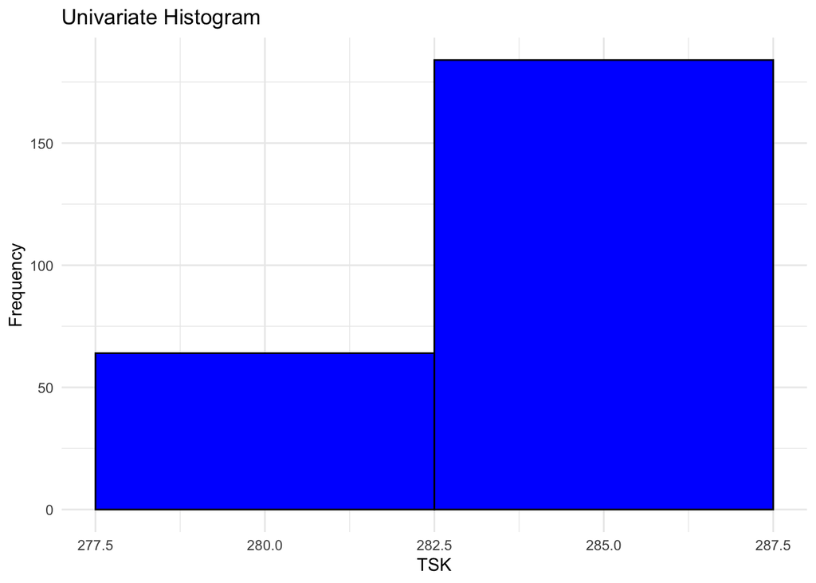

```r
ggplot(data = dataset, aes(x = TSK)) +
  geom_histogram(binwidth = 5, fill = "blue", color = "black") +
  labs(title = "Univariate Histogram", x = "TSK", y = "Frequency") +
  theme_minimal()
```

## Statistical Analysis

```r
for (col in names(dataset)) {
  if (is.numeric(dataset[[col]]) && length(unique(dataset[[col]])) > 1) {
    test_result <- shapiro.test(dataset[[col]])

    cat("Shapiro-Wilk Test for", col, ":", "\n")
    print(test_result)
    cat("\n")
  } else {
    cat("Cannot perform Shapiro-Wilk test for", col, "because all values are identical or non-numeric.", "\n")
  }
}
```

```
## Cannot perform Shapiro-Wilk test for dateTime because all values are identical or non-numeric.
## Shapiro-Wilk Test for TSK :
##
##  Shapiro-Wilk normality test
##
## data:  dataset[[col]]
## W = 0.92405, p-value = 5.882e-10
##
##
## Shapiro-Wilk Test for PSFC :
##
##  Shapiro-Wilk normality test
##
## data:  dataset[[col]]
## W = 0.94969, p-value = 1.485e-07
##
##
## Shapiro-Wilk Test for U10 :
##
##  Shapiro-Wilk normality test
##
## data:  dataset[[col]]
## W = 0.96214, p-value = 4.016e-06
##
##
## Shapiro-Wilk Test for V10 :
##
##  Shapiro-Wilk normality test
##
## data:  dataset[[col]]
## W = 0.97041, p-value = 4.992e-05
##
##
## Shapiro-Wilk Test for Q2 :
##
##  Shapiro-Wilk normality test
##
## data:  dataset[[col]]
## W = 0.95373, p-value = 4.093e-07
##
##
## Cannot perform Shapiro-Wilk test for RAINC because all values are identical or non-numeric.
## Shapiro-Wilk Test for RAINNC :
##
##  Shapiro-Wilk normality test
##
## data:  dataset[[col]]
## W = 0.28426, p-value < 2.2e-16
##
##
## Cannot perform Shapiro-Wilk test for SNOW because all values are identical or non-numeric.
## Cannot perform Shapiro-Wilk test for TSLB because all values are identical or non-numeric.
## Cannot perform Shapiro-Wilk test for SMOIS because all values are identical or non-numeric.
## Cannot perform Shapiro-Wilk test for date because all values are identical or non-numeric.
## Cannot perform Shapiro-Wilk test for time because all values are identical or non-numeric.
```

The Shapiro-Wilk test is a statistical test used to assess whether a given dataset follows a normal distribution. The interpretation of the results typically involves examining the p-value associated with the test statistic, denoted as 𝑊. The result of the Shapiro test states that the columns (TSK, PSFC, U10, V10 and Q2) are not normally distributed.

```r
cols_to_standardize <- c("TSK", "PSFC", "U10", "V10", "Q2")

# Apply Z-score normalization to selected columns
dataset_standardized <- as.data.frame(scale(dataset[cols_to_standardize]))

# View the standardized dataset
head(dataset_standardized)
```

```
##         TSK      PSFC      U10        V10        Q2
## 1 -1.770142 -3.392959 1.925937 -1.7861776 -1.502031
## 2 -1.770142 -3.025298 1.925937 -1.4656529 -1.554167
## 3 -1.770142 -2.698300 1.925937 -0.9848658 -1.713703
## 4 -1.770142 -2.169682 1.925937 -0.5727626 -1.713703
## 5 -1.770142 -1.719001 1.925937  0.8467041 -1.713703
## 6 -1.770142 -1.630897 1.294873  1.8220151 -1.713703
```

```r
for (col in names(dataset_standardized)) {

  if (is.numeric(dataset_standardized[[col]])) {
    test_result <- shapiro.test(dataset_standardized[[col]])


    cat("Shapiro-Wilk Test for", col, ":", "\n")
    print(test_result)
    cat("\n")
  }
}
```

```
## Shapiro-Wilk Test for TSK :
##
##  Shapiro-Wilk normality test
##
## data:  dataset_standardized[[col]]
## W = 0.92405, p-value = 5.882e-10
##
##
## Shapiro-Wilk Test for PSFC :
##
##  Shapiro-Wilk normality test
##
## data:  dataset_standardized[[col]]
## W = 0.94969, p-value = 1.485e-07
##
##
## Shapiro-Wilk Test for U10 :
##
##  Shapiro-Wilk normality test
##
## data:  dataset_standardized[[col]]
## W = 0.96214, p-value = 4.016e-06
##
##
## Shapiro-Wilk Test for V10 :
##
##  Shapiro-Wilk normality test
##
## data:  dataset_standardized[[col]]
## W = 0.97041, p-value = 4.992e-05
##
##
## Shapiro-Wilk Test for Q2 :
##
##  Shapiro-Wilk normality test
##
## data:  dataset_standardized[[col]]
## W = 0.95373, p-value = 4.093e-07
```

The result indicates that after apply z-score normalization, the data is not normally distributed

```r
lm_model <- lm(TSK ~ Q2, data = dataset)

# Print summary of the regression model
print(summary(lm_model))
```

```
##
## Call:
## lm(formula = TSK ~ Q2, data = dataset)
##
## Residuals:
##     Min      1Q  Median      3Q     Max
## -1.5601 -0.4103 -0.1939  0.2794  2.5692
##
## Coefficients:
##              Estimate Std. Error t value Pr(>|t|)
## (Intercept)  272.8720     0.3084  884.91   <2e-16 ***
## Q2          1433.4106    42.1068   34.04   <2e-16 ***
## ---
## Signif. codes:  0 '***' 0.001 '**' 0.01 '*' 0.05 '.' 0.1 ' ' 1
##
## Residual standard error: 0.6346 on 246 degrees of freedom
## Multiple R-squared:  0.8249, Adjusted R-squared:  0.8242
## F-statistic:  1159 on 1 and 246 DF,  p-value: < 2.2e-16
```

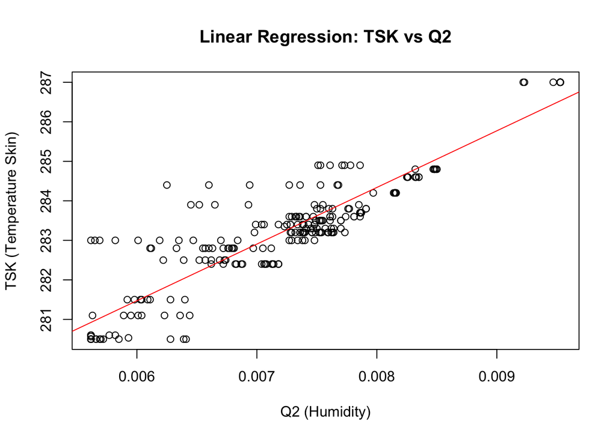

```r
# Plot the data points and the regression line
plot(dataset$Q2, dataset$TSK, main = "Linear Regression: TSK vs Q2",
     xlab = "Q2 (Humidity)", ylab = "TSK (Temperature Skin)")
abline(lm_model, col = "red")
```

The result above shows there is a linear correlation with the TSK and Q2 variables. I will now apply Multiple Linear Regression to the data.

```r
#install.packages("car")
library(car)
# Fit the linear regression model
model <- lm(TSK ~ Q2 + PSFC + U10 + V10, data = dataset)

# Calculate VIF for each predictor variable
vif_values <- car::vif(model)
vif_values
```

```
##       Q2     PSFC      U10      V10
## 1.681235 1.416147 1.656412 1.363693
```

```r
#install packages
#install.packages("ggplot")
#install.packages("caret")
#install.packages("randomForest")
#install.packages("glmnet")
#install.packages("e1071")

library(caret)
library(randomForest)
library(glmnet)
library(e1071)

# Split the data into training and testing sets ( 80% training, 20% testing)

trainIndex <- createDataPartition(dataset$TSK, p = 0.8, list = FALSE)
train_data <- dataset[trainIndex, ]
test_data <- dataset[-trainIndex, ]

# Feature selection for Linear Regression (e.g., Lasso Regression)
lasso_model <- cv.glmnet(as.matrix(train_data[, c("PSFC", "U10", "V10", "Q2")]), train_data$TSK, alpha = 1)
lasso_selected_features <- predict(lasso_model, s = "lambda.min", newx = as.matrix(train_data[, c("PSFC", "U10", "V10", "Q2")]))
lasso_selected_features <- which(lasso_selected_features != 0)

# Train Linear Regression model
lm_model <- lm(TSK ~ PSFC + U10 + V10 + Q2, data = train_data)

# Train Decision Tree model
dt_model <- train(TSK ~ PSFC + U10 + V10 + Q2, data = train_data, method = "rpart")
# Train RandomForestRegressor model
rf_model <- randomForest(TSK ~ PSFC + U10 + V10 + Q2, data = train_data)

# Train SVM model
svm_model <- svm(TSK ~ PSFC + U10 + V10 + Q2, data = train_data, kernel = "linear")

# Evaluate models on the testing set
lm_pred <- predict(lm_model, newdata = test_data)
dt_pred <- predict(dt_model, newdata = test_data)
rf_pred <- predict(rf_model, newdata = test_data)
svm_pred <- predict(svm_model, newdata = test_data)

# Calculate evaluation metrics
lm_mae <- mean(abs(lm_pred - test_data$TSK))
dt_mae <- mean(abs(dt_pred - test_data$TSK))
rf_mae <- mean(abs(rf_pred - test_data$TSK))
svm_mae <- mean(abs(svm_pred - test_data$TSK))

lm_mse <- mean((lm_pred - test_data$TSK)^2)
dt_mse <- mean((dt_pred - test_data$TSK)^2)
rf_mse <- mean((rf_pred - test_data$TSK)^2)
svm_mse <- mean((svm_pred - test_data$TSK)^2)

lm_r_squared <- cor(lm_pred, test_data$TSK)^2
dt_r_squared <- cor(dt_pred, test_data$TSK)^2
rf_r_squared <- cor(rf_pred, test_data$TSK)^2
svm_r_squared <- cor(svm_pred, test_data$TSK)^2

cat("Linear Regression MAE:", lm_mae, "\n")
```

```
## Linear Regression MAE: 0.4080205
```